# Practical Machine Learning - Course Project

Neel Vashisht

24/10/2020

## Overview

Using devices such as Jawbone Up, Nike FuelBand, and Fitbit it is now possible to collect a large amount of data about personal activity relatively inexpensively. Fortunately, the enthusiasts of tech world and fitness, love tracking and quantifying their physical activities, be it running, workouts, swimming, etc. But the quality of those workouts does not get measured. In this project, we will attempt to measure the quality of the activities performed.

```r
library(caret)
library(rattle)
library(rpart)
library(rpart.plot)
```

### Getting data

For data we’re using the data set provided in http://web.archive.org/web/20161224072740/http:/groupware.les.inf.puc-rio.br/har. A very well written article now residing in web archive.

```r
trainSet <- read.csv("~/R/pml-training.csv")
testSet <- read.csv("~/R/pml-testing.csv")
dim(trainSet)
```

```
## [1] 19622   160
```

```r
dim(testSet)
```

```
## [1]  20 160
```

The data set contains a lot of variables (160) which we don’t need.

## Cleaning data

To remove the variables we don’t need, we’ll use

```r
removeCol <- which(colSums(is.na(trainSet) | trainSet=="") > 0.9 * dim(trainSet)[1])
trainSetClean <- trainSet[,-removeCol]
trainSetClean <- trainSetClean[,-c(1:7)]
dim(trainSetClean)
```

```
## [1] 19622    53
```

```r
# test set
removeCol <- which(colSums(is.na(testSet) | testSet=="") > 0.9 * dim(testSet)[1])
testSetClean <- testSet[,-removeCol]
testSetClean <- testSetClean[,-1]
dim(testSetClean)
```

```
## [1] 20 59
```

### Training and testing

We now cleaned training set into a pure training data set (75%) and a validation data set (25%). The 25% will be used for validation at the end of training the model.

```r
set.seed(12345)
intrainData <- createDataPartition(trainSetClean$classe, p=0.75, list=FALSE)
trainData <- trainSetClean[intrainData,]
testData <- trainSetClean[-intrainData,]
dim(trainData)
```

```
## [1] 14718    53
```

## Data Modeling

For data modeling, we use random forest for easier sailing, using three fold cross validation method.

```r
controlRF <- trainControl(method="cv", number=3)
#model_CT <- train(classe~., data=trainData, method="rpart", trControl=trControl)
modelRF <- train(classe~., data=trainData, method="rf", trControl=controlRF, verbose=FALSE)
```

## Decision Tree

The decision formed will look like this:

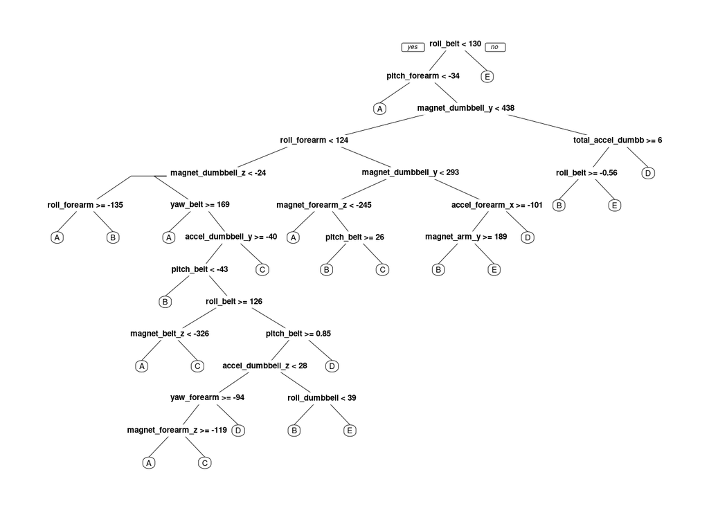

```r
tree <- rpart(classe ~ ., data=trainData, method="class")
prp(tree)
```

## Testing the model

For testing we’ll use the 25% unused data from the original training set.

```r
trainpred <- predict(modelRF,newdata=testData)

cmat <- confusionMatrix(testData$classe,trainpred)

# model accuracy
cmat$overall[1]
```

```
##  Accuracy
## 0.9946982
```

The accuracy comes out fairly good.

## End Result

For the last, we use the actual tests to test out the model developed in the report.

```r
FinalTestPred <- predict(modelRF,newdata=testSetClean)
FinalTestPred
```

```
##  [1] B A B A A E D B A A B C B A E E A B B B
## Levels: A B C D E
```